# R Notebook

Leticia Salazar

09/05/2022

$~$

### **Data 608 - Module 1: Principles of Data Visualization and Introduction to ggplot2**

$~$

#### I have provided you with data about the 5,000 fastest growing companies in the US, as compiled by Inc. magazine. Lets read this in:

```r
inc <- read.csv("https://raw.githubusercontent.com/charleyferrari/CUNY_DATA_608/master/module1/Data/inc5000_data.csv", header= TRUE)
```

$~$

#### And lets preview this data:

```r
head(inc)
```

|  | Rank | Name | Growth_Rate | Revenue | Industry | Employees | City | State |
| --- | --- | --- | --- | --- | --- | --- | --- | --- |
| 1 | 1 | Fuhu | 421.48 | 117900000 | Consumer Products & Services | 104 | El Segundo | CA |
| 2 | 2 | FederalConference.com | 248.31 | 49600000 | Government Services | 51 | Dumfries | VA |
| 3 | 3 | The HCI Group | 245.45 | 25500000 | Health | 132 | Jacksonville | FL |
| 4 | 4 | Bridger | 233.08 | 1900000000 | Energy | 50 | Addison | TX |
| 5 | 5 | DataXu | 213.37 | 87000000 | Advertising & Marketing | 220 | Boston | MA |
| 6 | 6 | MileStone Community Builders | 179.38 | 45700000 | Real Estate | 63 | Austin | TX |

```r
summary(inc)
```

```
      Rank          Name            Growth_Rate         Revenue            Industry           Employees           City              State
 Min.   :   1   Length:5001        Min.   :  0.340   Min.   :2.000e+06   Length:5001        Min.   :    1.0   Length:5001        Length:5001
 1st Qu.:1252   Class :character   1st Qu.:  0.770   1st Qu.:5.100e+06   Class :character   1st Qu.:   25.0   Class :character   Class :character
 Median :2502   Mode  :character   Median :  1.420   Median :1.090e+07   Mode  :character   Median :   53.0   Mode  :character   Mode  :character
 Mean   :2502                      Mean   :  4.612   Mean   :4.822e+07                      Mean   :  232.7
 3rd Qu.:3751                      3rd Qu.:  3.290   3rd Qu.:2.860e+07                      3rd Qu.:  132.0
 Max.   :5000                      Max.   :421.480   Max.   :1.010e+10                      Max.   :66803.0
                                                                                            NA's   :12
```

$~$

#### Think a bit on what these summaries mean. Use the space below to add some more relevant non-visual exploratory information you think helps you understand this data:

```r
# Loading libraries
library(tidyverse)
library(ggplot2)
library(psych)
```

```r
# Insert your code here, create more chunks as necessary

# Offers an overview of what the data looks like, has 5,001 rows with 8 columns, along with the column names
glimpse(inc)
```

```
Rows: 5,001
Columns: 8
$ Rank        <int> 1, 2, 3, 4, 5, 6, 7, 8, 9, 10, 11, 12, 13, 14, 15, 16, 17, 18, 19, 20, 21, 22, 23, 24, 25, 26, 27, 28, 29, 30, 31, 32, 33, 34, 35, 36, 37, 38, 39, 40, 41, 42, 43, 44, 45, 46, …
$ Name        <chr> "Fuhu", "FederalConference.com", "The HCI Group", "Bridger", "DataXu", "MileStone Community Builders", "Value Payment Systems", "Emerge Digital Group", "Goal Zero", "Yagoozon"…
$ Growth_Rate <dbl> 421.48, 248.31, 245.45, 233.08, 213.37, 179.38, 174.04, 170.64, 169.81, 166.89, 164.33, 150.65, 141.02, 128.63, 123.33, 110.68, 105.73, 104.62, 100.10, 92.45, 90.44, 87.82, 87…
$ Revenue     <dbl> 1.179e+08, 4.960e+07, 2.550e+07, 1.900e+09, 8.700e+07, 4.570e+07, 2.550e+07, 2.390e+07, 3.310e+07, 1.860e+07, 2.960e+07, 3.410e+07, 1.700e+07, 2.110e+07, 5.360e+08, 1.430e+07,…
$ Industry    <chr> "Consumer Products & Services", "Government Services", "Health", "Energy", "Advertising & Marketing", "Real Estate", "Financial Services", "Advertising & Marketing", "Consumer…
$ Employees   <int> 104, 51, 132, 50, 220, 63, 27, 75, 97, 15, 149, 165, 250, 160, 4100, 26, 15, 11, 51, 107, 30, 41, 1016, 74, 150, 17, 75, 1100, 260, 79, 30, 50, 32, 10, 15, 110, 27, 89, 675, 9…
$ City        <chr> "El Segundo", "Dumfries", "Jacksonville", "Addison", "Boston", "Austin", "Nashville", "San Francisco", "Bluffdale", "Warwick", "Tysons Corner", "San Francisco", "Orlando", "Ch…
$ State       <chr> "CA", "VA", "FL", "TX", "MA", "TX", "TN", "CA", "UT", "RI", "VA", "CA", "FL", "SC", "DC", "CA", "NJ", "FL", "OH", "CA", "WA", "TX", "TX", "ME", "TX", "NY", "CO", "FL", "TX", "…
```

```r
# looking deeper into the data set with the describe function
describe(inc)
```

|  | vars | n | mean | sd | median | trimmed | mad | min | max | range | skew | kurtosis | se |
| --- | --- | --- | --- | --- | --- | --- | --- | --- | --- | --- | --- | --- | --- |
| Rank | 1 | 5001 | 2501.64 | 1443.51 | 2502.00 | 2501.73 | 1853.25 | 1.00 | 5000.00 | 4999.00 | 0.00 | -1.20 | 20.41 |
| Name* | 2 | 5001 | 2501.00 | 1443.81 | 2501.00 | 2501.00 | 1853.25 | 1.00 | 5001.00 | 5000.00 | 0.00 | -1.20 | 20.42 |
| Growth_Rate | 3 | 5001 | 4.61 | 14.12 | 1.42 | 2.14 | 1.22 | 0.34 | 421.48 | 421.14 | 12.55 | 242.34 | 0.20 |
| Revenue | 4 | 5001 | 48222535.49 | 240542281.14 | 10900000.00 | 17334966.26 | 10674720.00 | 2000000.00 | 10100000000.00 | 10098000000.00 | 22.17 | 722.66 | 3401441.44 |
| Industry* | 5 | 5001 | 12.10 | 7.33 | 13.00 | 12.05 | 8.90 | 1.00 | 25.00 | 24.00 | -0.10 | -1.18 | 0.10 |
| Employees | 6 | 4989 | 232.72 | 1353.13 | 53.00 | 81.78 | 53.37 | 1.00 | 66803.00 | 66802.00 | 29.81 | 1268.67 | 19.16 |
| City* | 7 | 5001 | 732.00 | 441.12 | 761.00 | 731.74 | 604.90 | 1.00 | 1519.00 | 1518.00 | -0.04 | -1.26 | 6.24 |
| State* | 8 | 5001 | 24.80 | 15.64 | 23.00 | 24.44 | 19.27 | 1.00 | 52.00 | 51.00 | 0.12 | -1.46 | 0.22 |

$~$

## Question 1

#### Create a graph that shows the distribution of companies in the dataset by State (ie how many are in each state). There are a lot of States, so consider which axis you should use. This visualization is ultimately going to be consumed on a ‘portrait’ oriented screen (ie taller than wide), which should further guide your layout choices.

##### *The bar chart below shows California is the top state with the largest amount of companies while Puerto Rico has the least.*

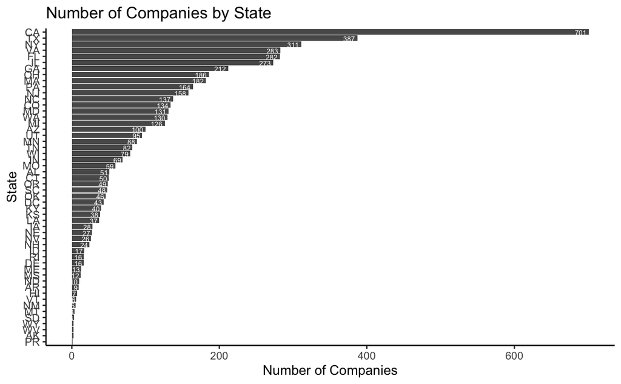

```r
# Answer Question 1 here

# sort by statem in descending order
ques_1 <- inc %>%
  group_by(State) %>%
  count(State) %>%
  arrange(desc(n)) %>%
  as_tibble(ques_1)

# plot bar chart
ggplot(ques_1, aes(x = reorder(State, n), y = n)) +
  geom_bar(stat = "identity") +
  theme_classic() +
  coord_flip() +
  xlab("State") +
  ylab("Number of Companies") +
  ggtitle("Number of Companies by State") +
  geom_text(aes(label = n), vjust = 0.6, hjust = 1.2, size = 2, color="white")
```

$~$

## Quesiton 2

#### Lets dig in on the state with the 3rd most companies in the data set. Imagine you work for the state and are interested in how many people are employed by companies in different industries. Create a plot that shows the average and/or median employment by industry for companies in this state (only use cases with full data, use R’s `complete.cases()` function.) In addition to this, your graph should show how variable the ranges are, and you should deal with outliers.

##### *Here’s a comparison for NY state and the country’s data set using boxplots. Notice the increase in outliers for the country’s plot than in NY and the change in mean and median for all the industries.*

```r
# Answer Question 2 here

# Based on question 1 we know NY is the third state with most companies so we filter it out
ny_state <- filter(inc, State == 'NY')
summary(ny_state)
```

```
      Rank          Name            Growth_Rate        Revenue            Industry           Employees           City              State
 Min.   :  26   Length:311         Min.   : 0.350   Min.   :2.000e+06   Length:311         Min.   :    1.0   Length:311         Length:311
 1st Qu.:1186   Class :character   1st Qu.: 0.670   1st Qu.:4.300e+06   Class :character   1st Qu.:   21.0   Class :character   Class :character
 Median :2702   Mode  :character   Median : 1.310   Median :8.800e+06   Mode  :character   Median :   45.0   Mode  :character   Mode  :character
 Mean   :2612                      Mean   : 4.371   Mean   :5.872e+07                      Mean   :  271.3
 3rd Qu.:4005                      3rd Qu.: 3.580   3rd Qu.:2.570e+07                      3rd Qu.:  105.5
 Max.   :4981                      Max.   :84.430   Max.   :4.600e+09                      Max.   :32000.0
```

```r
# using the whole data set to compare NY with
summary(inc)
```

```
      Rank          Name            Growth_Rate         Revenue            Industry           Employees           City              State
 Min.   :   1   Length:5001        Min.   :  0.340   Min.   :2.000e+06   Length:5001        Min.   :    1.0   Length:5001        Length:5001
 1st Qu.:1252   Class :character   1st Qu.:  0.770   1st Qu.:5.100e+06   Class :character   1st Qu.:   25.0   Class :character   Class :character
 Median :2502   Mode  :character   Median :  1.420   Median :1.090e+07   Mode  :character   Median :   53.0   Mode  :character   Mode  :character
 Mean   :2502                      Mean   :  4.612   Mean   :4.822e+07                      Mean   :  232.7
 3rd Qu.:3751                      3rd Qu.:  3.290   3rd Qu.:2.860e+07                      3rd Qu.:  132.0
 Max.   :5000                      Max.   :421.480   Max.   :1.010e+10                      Max.   :66803.0
                                                                                            NA's   :12
```

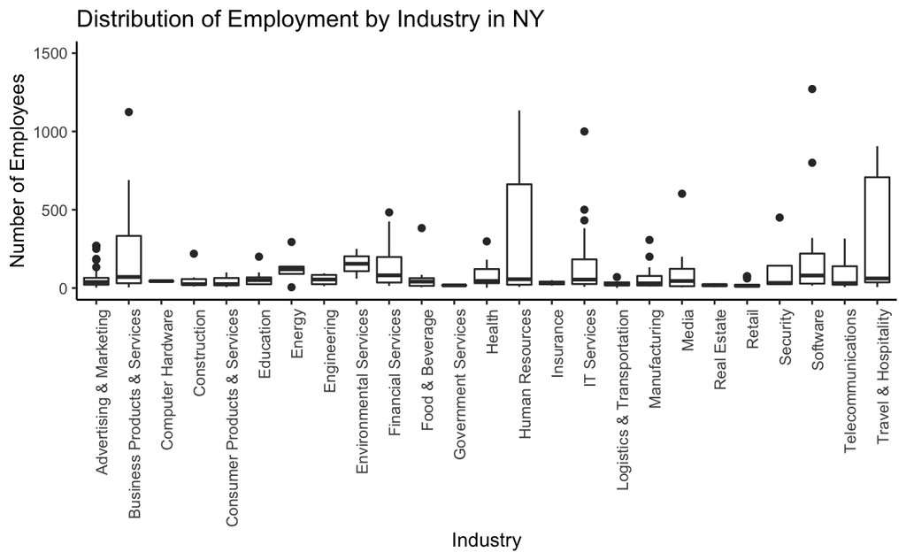

```r
# plotting NY state
ques_2a <- ny_state %>%
  filter(complete.cases(.)) %>% # complete cases only
  group_by(Industry) %>%
  select(Industry, Employees)

# boxplot showing NY by industry
ggplot(ques_2a, mapping = aes(x = Industry, y = Employees)) +
  geom_boxplot() +
  theme_classic() +
  labs(title = 'Distribution of Employment by Industry in NY', x = 'Industry', y = 'Number of Employees') +
  coord_cartesian(ylim = c(0, 1500)) +
  theme(axis.text.x = element_text(angle = 90, hjust = 1))
```

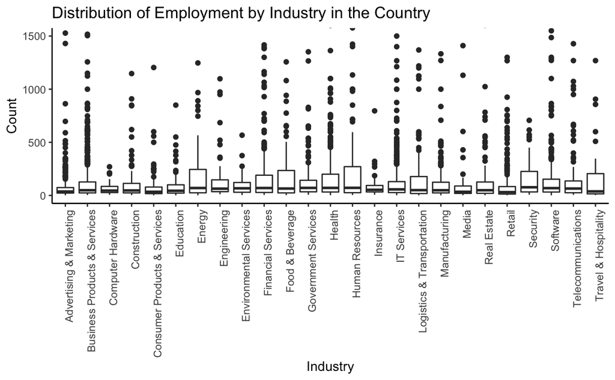

```r
# comparison plot of the country
ques_2b <- inc %>%
  filter(complete.cases(.)) %>% # complete cases only
  group_by(Industry) %>%
  select(Industry, Employees)

ggplot(ques_2b, mapping = aes(x = Industry, y = Employees)) +
  geom_boxplot() +
  theme_classic() +
  labs(title = 'Distribution of Employment by Industry in the Country', x = 'Industry', y = 'Count') +
  coord_cartesian(ylim = c(0, 1500)) +
  theme(axis.text.x = element_text(angle = 90, hjust = 1))
```

$~$

## Question 3

#### Now imagine you work for an investor and want to see which industries generate the most revenue per employee. Create a chart that makes this information clear. Once again, the distribution per industry should be shown.

##### *The charts created below assumes we are still looking into NY state but I also created a chart for the country’s data. In terms of which industries generate the most revenue, for NY you have Energy, Logistics & Transportation and IT services as the top 3. While for the country we have Computer Hardware, Energy and Construction.*

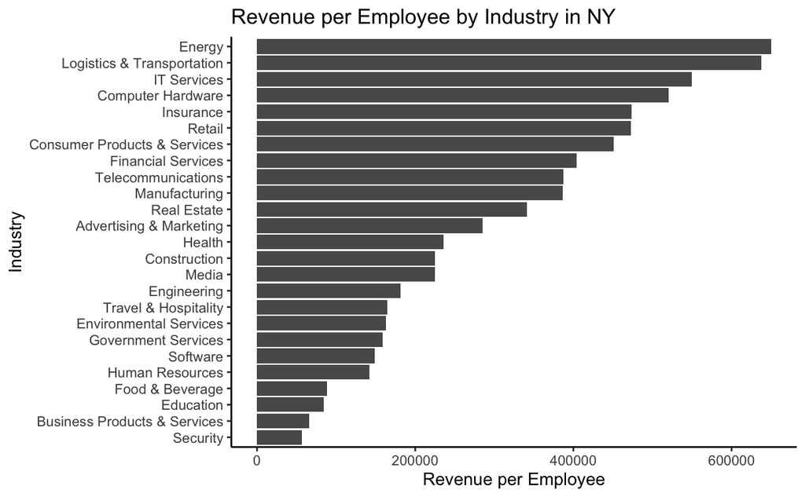

```r
# turning off scientific notiation
options(scipen = 999)

# showing NY state only
ques_3a <- ny_state %>%
  group_by(Industry) %>%
  summarize(total_rev = sum(Revenue), total_emp = sum(Employees), rev_per_emp = total_rev/total_emp) %>%
  arrange(desc(rev_per_emp)) %>%
  na.omit()

ggplot(ques_3a, aes(x = reorder(Industry, rev_per_emp), y = rev_per_emp)) +
  geom_bar(stat = "identity") +
  labs(title = "Revenue per Employee by Industry in NY", x = "Industry", y = "Revenue per Employee") +
  theme_classic() +
  coord_flip()
```

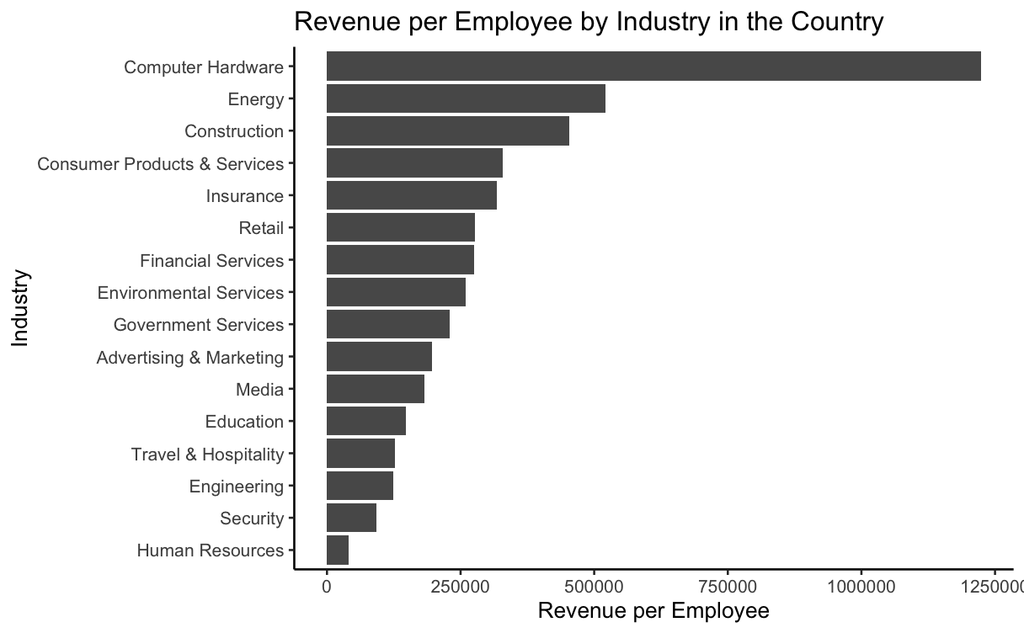

```r
# Answer Question 3 here

# showing the country as a whole
ques_3b <- inc %>%
  group_by(Industry) %>%
  summarize(total_rev = sum(Revenue), total_emp = sum(Employees), rev_per_emp = total_rev/total_emp) %>%
  arrange(desc(rev_per_emp)) %>%
  na.omit()

ggplot(ques_3b, aes(x = reorder(Industry, rev_per_emp), y = rev_per_emp)) +
  geom_bar(stat = "identity") +
  labs(title = "Revenue per Employee by Industry in the Country", x = "Industry", y = "Revenue per Employee") +
  theme_classic() +
  coord_flip()
```

#### References:

- Scientific Notation Removal